# 1. Produce and evaluate direction predictions for COVID hospitalizations

In this document, we assess our predictions of a simple definition of direction. First we get the data.

```r
# Load the evaluations
evals <- readRDS(file.path(analysis_dir, paste(analysis_type,"prediction.rds",sep = "-")))
evals <- evals %>% rename(target_date = target_end_date)

# Load the trained models
forecasters <- unique(evals$forecaster)
trained_models <- lapply(forecasters, FUN = function(forecaster){
  readRDS_from_dir(file.path(model_dir,forecaster))
})
names(trained_models) <- forecasters

# Create coefficient dfs
coefs <- lapply(trained_models,create_coef_df) %>%
  bind_rows(.id = "forecaster") %>%
  mutate(feature_name = parse_feature_name(feature_name))

# Omit whatever was asked to be omitted.
evals <- evals %>% filter(!(forecaster %in% omitted_forecasters) &
                          !(ahead %in% omitted_aheads) &
                          !(forecast_date %in% omitted_forecast_dates))
coefs <- coefs %>% filter(!(forecaster %in% omitted_forecasters) &
                      !(ahead %in% omitted_aheads) &
                      !(forecast_date %in% omitted_forecast_dates))
```

Our forecasting parameters are:

- Geographical resolution: state
- Forecast date range: 2020-09-01 to 2021-11-01
- Number of days ahead forecast: 7 to 21.

Direction are defined as in Dmitry’s notebook. The parameters used to define direction are

- $w$ (width of time interval): 7
- *upswing threshold* (ratio of expected present - expected past value over expected past value under null hypothesis): .1
- *minimum threshold* (minimum number of cases needed at past value in order to qualify) 130/7.

Let $N_i^{t}$ denote the number of observed admissions at a given {location,day}. Let $\bar{N}_i^{t}(w) = \frac{1}{w}\sum_{s = t - w + 1}^{t} N_i^{s}$ denote the $w$-day trailing average. A given {location,day,ahead} triplet qualifies as an increase

$$\frac{\bar{N}_i^{t + a} - \bar{N}_i^{t}}{\bar{N}_{i}^{t}} \geq s_0~~\textrm{and}~~ \bar{N}_i^{t} \geq t_0$$
where $s_0$ is the upswing threshold, and $t_0$ is the minimum threshold. If $N_i^{t} < t_0$, then the response is coded as NA (i.e. thrown out).

# Data wrangling

We restrict outselves to evaluation on a “reasonable” subset of {location,forecast_date,forecaster} triplets.

```r
## Handle missing predictions.

# Filter to common forecast dates
common_forecast_dates <- find_common_forecast_dates(evals)
evals <- evals %>% filter(forecast_date %in% common_forecast_dates)
coefs <- coefs %>% filter(forecast_date %in% common_forecast_dates)

# Now, we do the follow operations in order.
#
# (1) We get rid of any forecaster which is NA
#   for more than max_forecaster_na of all tasks.
#
# (2) We get rid of any location for which a remaining forecaster has been NA
#   for more than max_location_na of all tasks.
#
# (3) We get rid of any remaining tasks at which a remaining forecaster has been
#   NA.
max_forecaster_na <- 1
max_location_na <- 1
n_forecast_date <- length(unique(evals$forecast_date))
n_ahead <- length(unique(evals$ahead))
n_locations <- length(unique(evals$geo_value))

na_tasks <- evals %>%
  filter(is.na(value) | is.na(actual)) %>%
  select(geo_value, forecaster, forecast_date, ahead)

na_prop_by_forecaster <- na_tasks %>%
  group_by(forecaster) %>%
  summarize(prop = n()/(n_forecast_date * n_ahead * n_locations), .groups = "drop")
na_forecasters <- na_prop_by_forecaster %>%
  filter(prop > max_forecaster_na) %>%
  pull(forecaster) %>% unique()
na_prop_by_location <- na_tasks %>%
  group_by(forecaster,geo_value) %>%
  summarize(prop = n() / (n_ahead * n_forecast_date),.groups = "drop") %>%
  filter(!(forecaster %in% na_forecasters))
na_locations <- na_prop_by_location %>%
  filter(prop > max_location_na) %>%
  pull(geo_value) %>% unique()
na_tasks <- na_tasks %>%
  filter(!(forecaster %in% na_forecasters | geo_value %in% na_locations ))%>%
  select(-forecaster) %>% distinct()

evals <- evals %>%
  filter(!(forecaster %in% na_forecasters | geo_value %in% na_locations)) %>%
  anti_join(na_tasks)
```

It’s easier to visualize our errors and estimated coefficients if we do some smoothing.

```r
Median <- function(x) median(x,na.rm = TRUE)
n = 14

# Compute ROC over all days.
TEMP_fun <- function(x,alpha = seq(.01,1,by = .01)){
  power <- roc(x$value,x$actual,alpha)
}
all_day_roc <- evals %>%
  select(forecaster,ahead,forecast_date,value,actual) %>%
  group_by(forecaster,ahead) %>%
  group_modify( ~ TEMP_fun(.x))

# Smooth out the estimated coefficients, using an n-day average.
smoothed_coefs <- coefs %>%
  group_by(forecaster,ahead,feature_name) %>%
  arrange(forecast_date) %>%
  group_modify(slide_one_group, slide_fun = ~ Median(.x$value),
               n = n, col_name = "value") %>%
  ungroup()

# Compute AUC over all days
all_day_evals <- evals %>%
  select(forecaster,ahead,forecast_date,value,actual) %>%
  group_by(forecaster,ahead) %>%
  summarize(auc = auc(value,actual,alpha = seq(0,1,by = .01)),.groups = "drop")

# Compute AUC over each day
one_day_evals <- evals %>%
  select(forecaster,ahead,forecast_date,value,actual) %>%
  group_by(forecaster,ahead,forecast_date) %>%
  summarize(auc = auc(value,actual,alpha = seq(0,1,by = .01)),.groups = "drop")

# Compute AUC over trailing n-day windows
smoothed_evals <- evals %>%
  select(forecaster,ahead,forecast_date,value,actual) %>%
  arrange(forecast_date) %>%
  group_by(forecaster,ahead) %>%
  group_modify(slide_one_group, slide_fun = ~auc(.x$value,.x$actual, alpha = seq(0,1,by = .01)),
               n = n, col_name = "auc") %>%
  distinct() %>%
  ungroup()

# Compute AUC over each month
per_month_evals <- evals %>%
  select(forecaster,ahead,forecast_date,value,actual) %>%
  mutate(forecast_month = lubridate::month(forecast_date)) %>%
  group_by(forecaster,ahead,forecast_month) %>%
  summarize(auc = auc(value,actual,alpha = seq(0,1,by = .01)),.groups = "drop")
```

# EDA

The proportion of places that qualify as an increase in direction, over time.

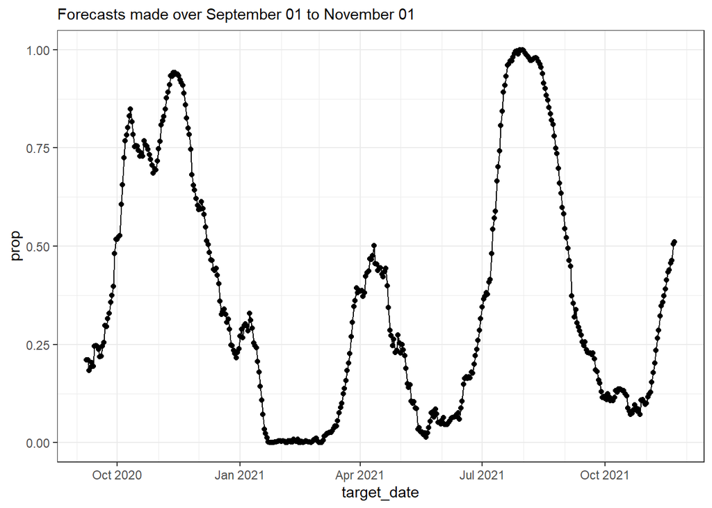

```r
# Plot the proportion of increases over time.
df <- evals %>%
  filter(forecaster == "AR3") %>%
  rename(direction = actual) %>%
  select(geo_value,target_date,direction) %>%
  group_by(target_date) %>%
  summarize(prop = sum(direction,na.rm = TRUE)/n(), .groups = "drop")

ggplot(df, aes(x = target_date, y = prop)) +
  geom_line() +
  geom_point() +
  scale_x_date(date_minor_breaks = "1 month") +
  labs(subtitle = subtitle)
```

# Receiver operator characteristic (ROC) curve, and area under the curve (AUC)

First up, ROC curves by ahead, aggregated over all days.

## ROC curves

### 7 days ahead

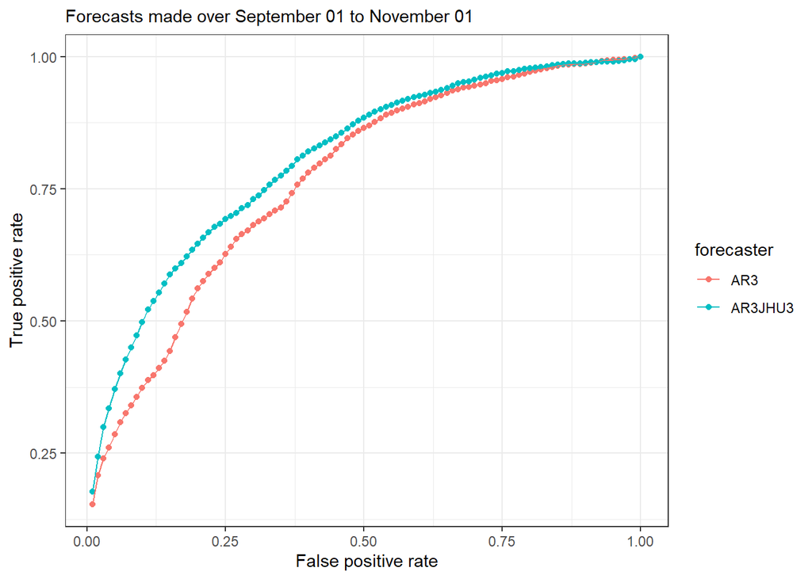

```r
ggplot(all_day_roc %>% filter(ahead == 7),
       aes(x = alpha, y = result, color = forecaster)) +
  geom_point() +
  geom_line() +
  labs(subtitle = subtitle,
       x = "False positive rate",
       y = "True positive rate")
```

### 10 days ahead

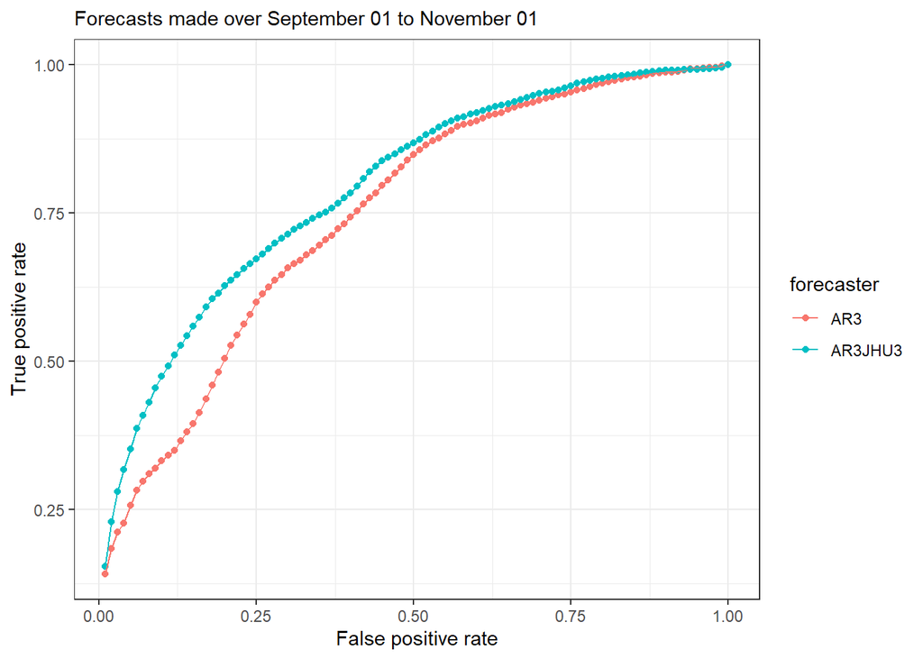

```r
ggplot(all_day_roc %>% filter(ahead == 10),
       aes(x = alpha, y = result, color = forecaster)) +
  geom_point() +
  geom_line() +
  labs(subtitle = subtitle,
       x = "False positive rate",
       y = "True positive rate")
```

### 14 days ahead

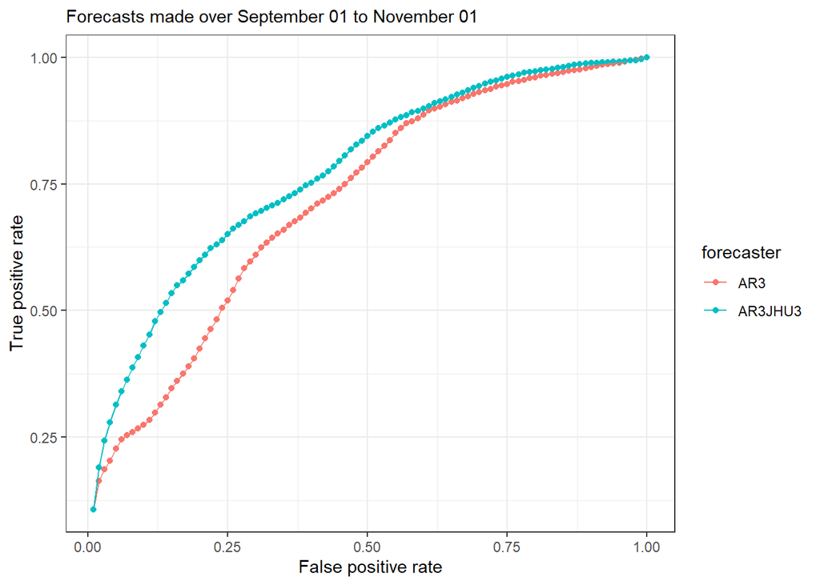

```r
ggplot(all_day_roc %>% filter(ahead == 14),
       aes(x = alpha, y = result, color = forecaster)) +
  geom_point() +
  geom_line() +
  labs(subtitle = subtitle,
       x = "False positive rate",
       y = "True positive rate")
```

### 21 days ahead

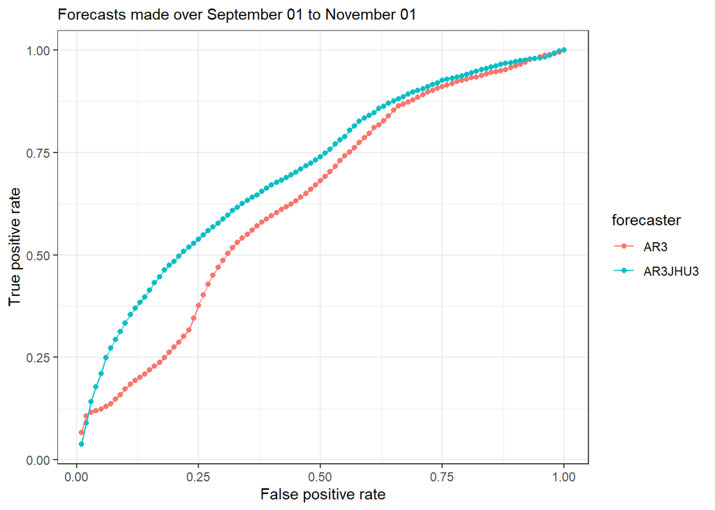

```r
ggplot(all_day_roc %>% filter(ahead == 21),
       aes(x = alpha, y = result, color = forecaster)) +
  geom_point() +
  geom_line() +
  labs(subtitle = subtitle,
       x = "False positive rate",
       y = "True positive rate")
```

Next up, AUC by ahead, aggregated over all dates. The tabs differ in the notion of aggregation:

- In the first tab, we aggregate by taking AUC over all forecast dates.
- In the second tab, we compute *AUC-per-day*—AUC on each day— then aggregate AUC-per-day using the mean.
- In the third tab, we compute *AUC-per-n-days*—AUC on each n-day windows—, then aggregate AUC-per-n-days using the mean.

## AUC curves by ahead

### AUC aggregation

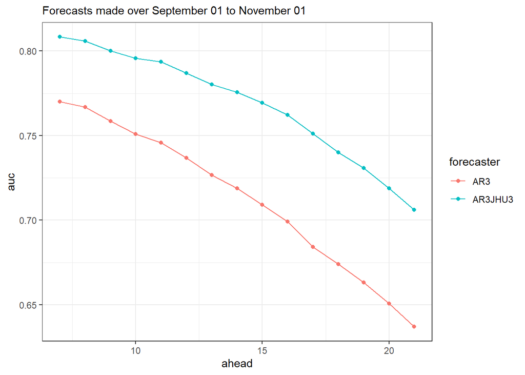

```r
ggplot(all_day_evals, aes(x = ahead, y = auc, color = forecaster)) +
  geom_point() +
  geom_line() +
  labs(subtitle = subtitle)
```

### AUC each day, mean aggregation

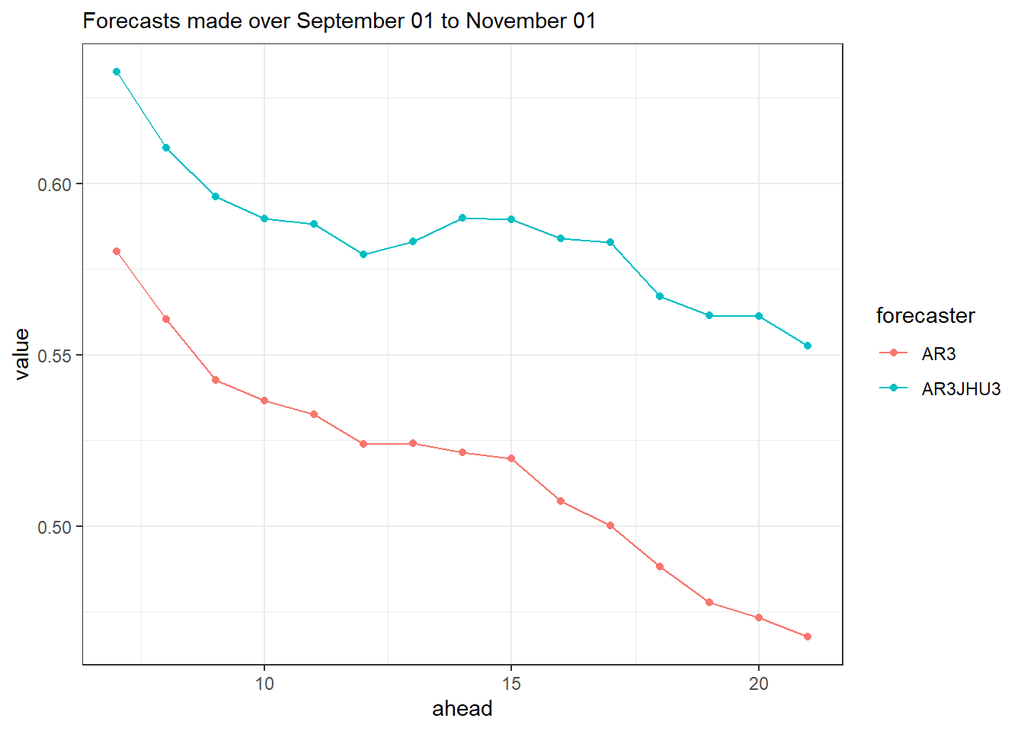

```r
ggplot(one_day_evals %>%
         group_by(forecaster,ahead) %>%
         summarise(value = mean(auc),.groups = "drop"),
       aes(x = ahead, y = value, color = forecaster)) +
  geom_point() +
  geom_line() +
  labs(subtitle = subtitle)
```

### AUC over n-day windows, mean aggregation

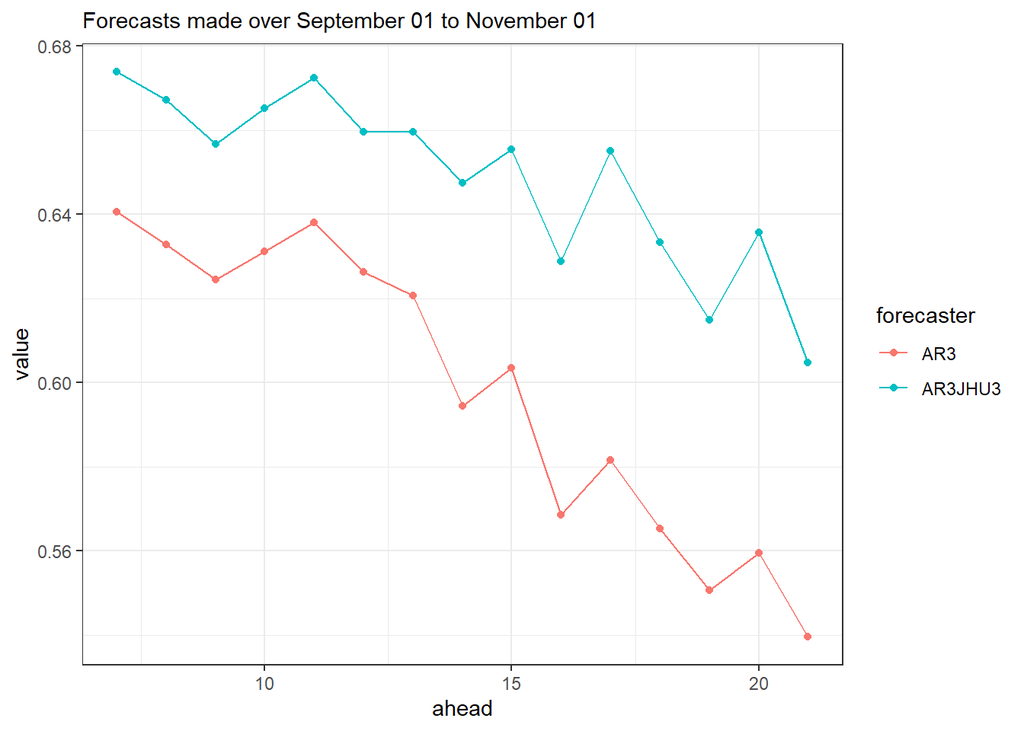

```r
ggplot(smoothed_evals %>%
         group_by(forecaster,ahead) %>%
         summarise(value = mean(auc),.groups = "drop"),
       aes(x = ahead, y = value, color = forecaster)) +
  geom_point() +
  geom_line() +
  labs(subtitle = subtitle)
```

## AUC over time

### Unsmoothed

#### 7 days ahead

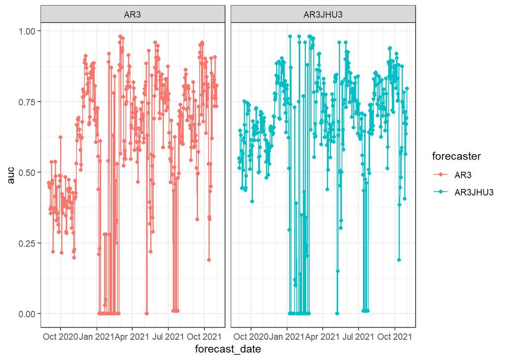

```r
ggplot(one_day_evals %>% filter(ahead == 7), aes(x = forecast_date, y = auc, color = forecaster)) +
           geom_point() +
           geom_line() +
           scale_x_date(date_minor_breaks = "1 month") +
           facet_wrap(vars(forecaster))
```

#### 10 days ahead

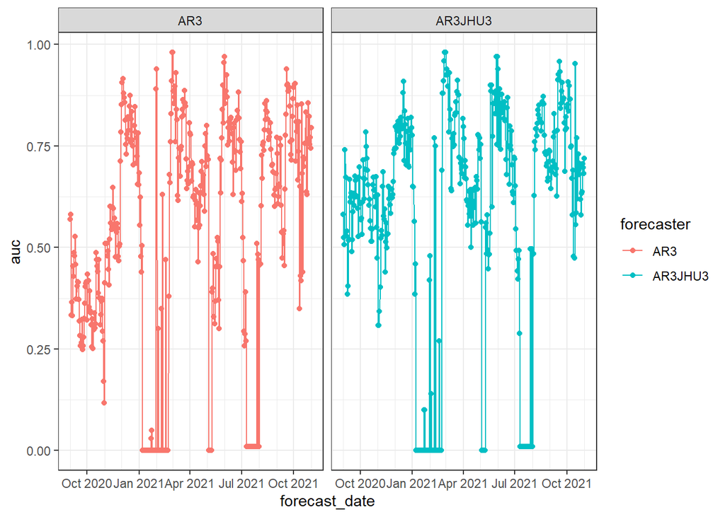

```r
ggplot(one_day_evals %>% filter(ahead == 10), aes(x = forecast_date, y = auc, color = forecaster)) +
           geom_point() +
           geom_line() +
           scale_x_date(date_minor_breaks = "1 month") +
           facet_wrap(vars(forecaster))
```

#### 14 days ahead

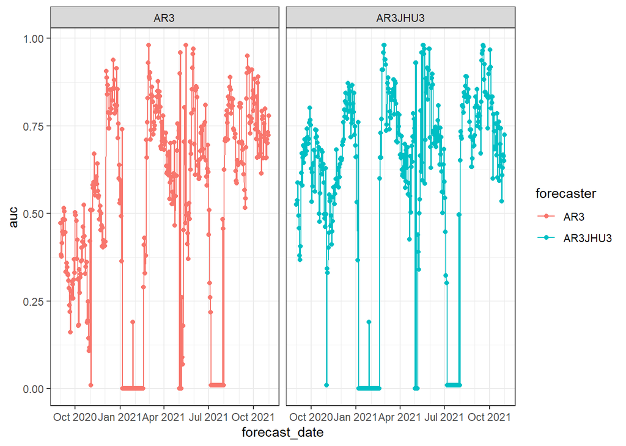

```r
ggplot(one_day_evals %>% filter(ahead == 14), aes(x = forecast_date, y = auc, color = forecaster)) +
           geom_point() +
           geom_line() +
           scale_x_date(date_minor_breaks = "1 month") +
           facet_wrap(vars(forecaster))
```

#### 21 days ahead

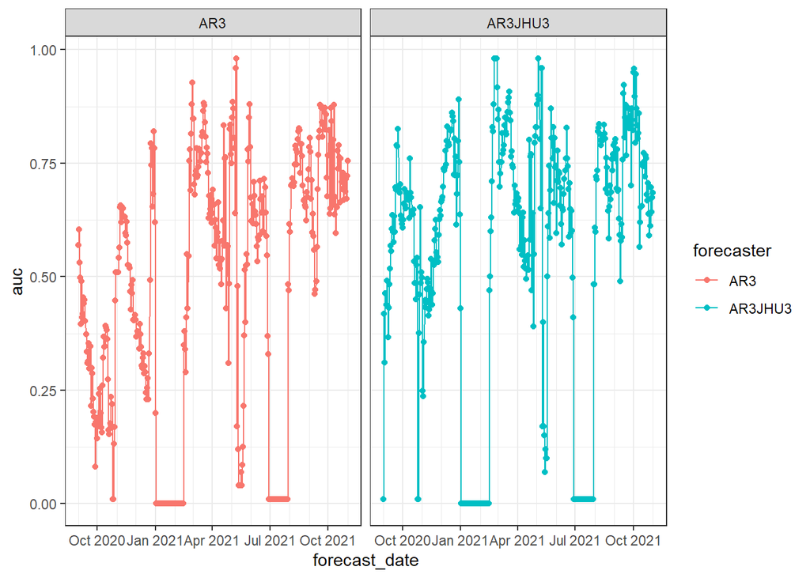

```r
ggplot(one_day_evals %>% filter(ahead == 21), aes(x = forecast_date, y = auc, color = forecaster)) +
           geom_point() +
           geom_line() +
           scale_x_date(date_minor_breaks = "1 month") +
           facet_wrap(vars(forecaster))
```

### Smoothed

#### 7 days ahead

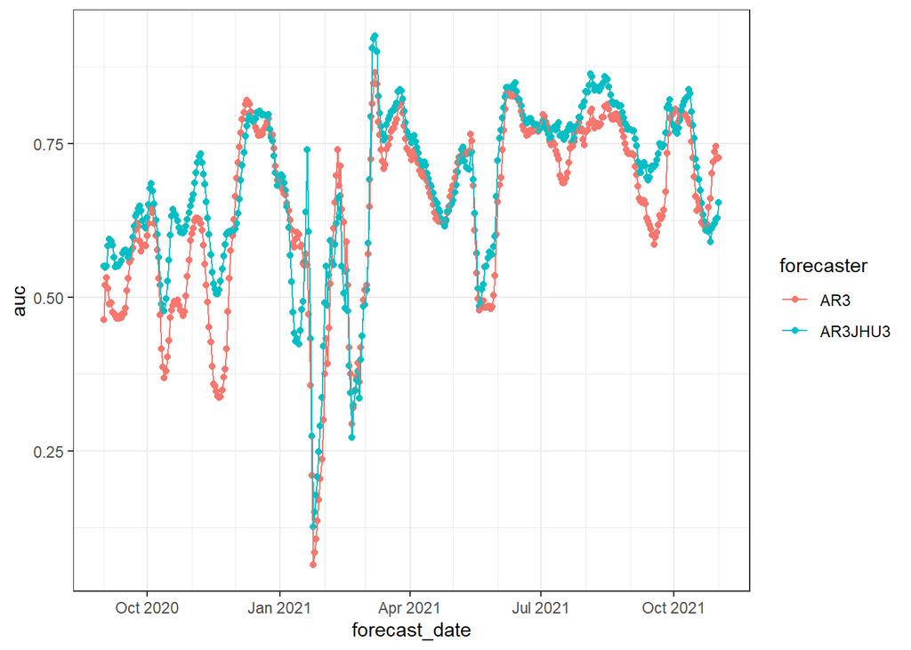

```r
ggplot(smoothed_evals %>% filter(ahead == 7), aes(x = forecast_date, y = auc, color = forecaster)) +
  geom_point() +
  geom_line() +
  scale_x_date(date_minor_breaks = "1 month")
```

#### 10 days ahead

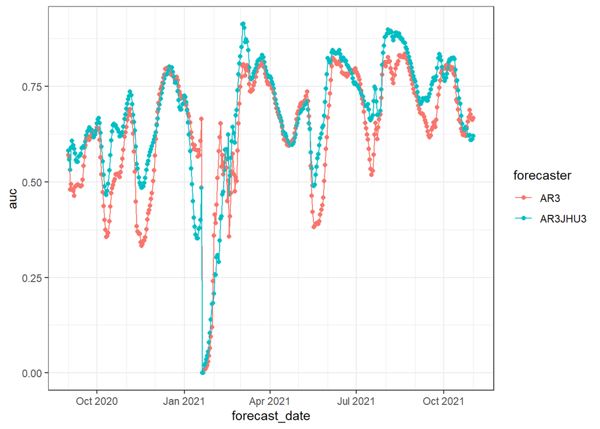

```r
ggplot(smoothed_evals %>% filter(ahead == 10), aes(x = forecast_date, y = auc, color = forecaster)) +
  geom_point() +
  geom_line() +
  scale_x_date(date_minor_breaks = "1 month")
```

#### 14 days ahead

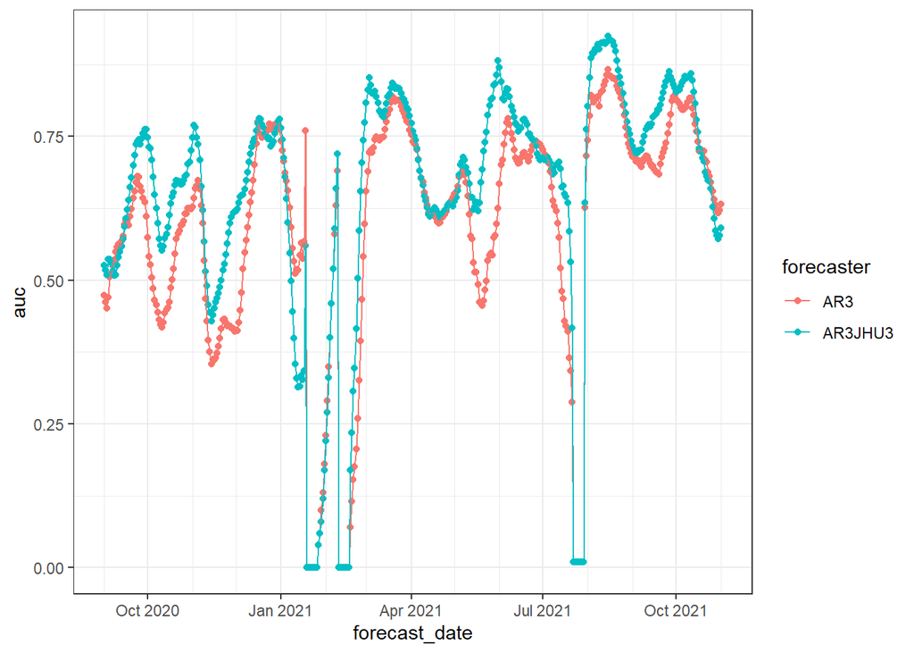

```r
ggplot(smoothed_evals %>% filter(ahead == 14), aes(x = forecast_date, y = auc, color = forecaster)) +
  geom_point() +
  geom_line() +
  scale_x_date(date_minor_breaks = "1 month")
```

#### 21 days ahead

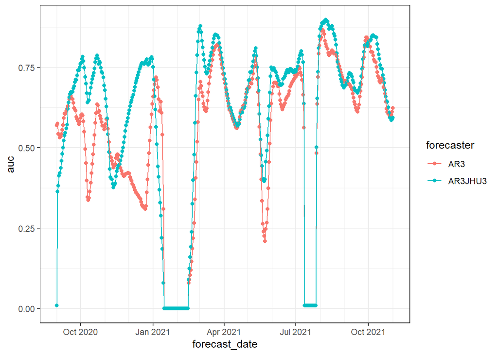

```r
ggplot(smoothed_evals %>% filter(ahead == 21), aes(x = forecast_date, y = auc, color = forecaster)) +
  geom_point() +
  geom_line() +
  scale_x_date(date_minor_breaks = "1 month")
```

### Per Month

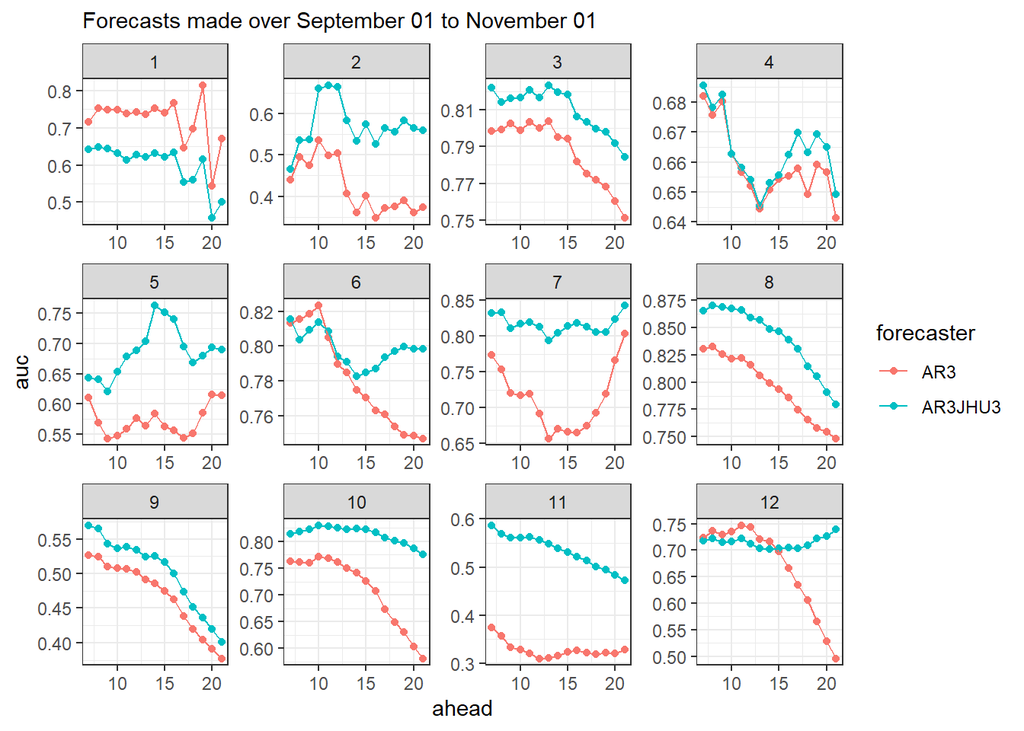

```r
ggplot(per_month_evals, aes(x = ahead, y = auc, color = forecaster)) +
  geom_point() +
  geom_line() +
  labs(subtitle = subtitle) +
  facet_wrap(vars(forecast_month), scales = "free")
```

# Estimated parameters

Estimated coefficients by value of ahead, aggregated over all dates.

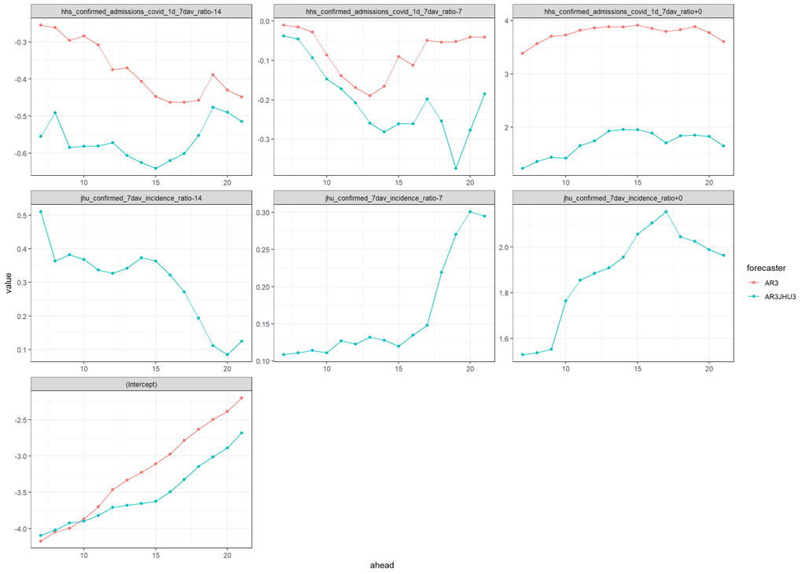

```r
# Average value of coefficient as a fxn of ahead
df <- coefs %>%
  group_by(ahead, feature_name, forecaster) %>%
  summarise(value = median(value), .groups = "drop")

ggplot(df, aes(x = ahead, y = value,color = forecaster)) +
  geom_point() +
  geom_line() +
  facet_wrap(vars(feature_name), scales = "free", ncol = 3)
```

Now, estimated coefficients over time, for `ahead = c(7,10,14,21)`. `Smoothed` tab indicate median was taken over 14-day trailing window.

## Parameter estimates over time

### Unsmoothed

#### 7 days ahead

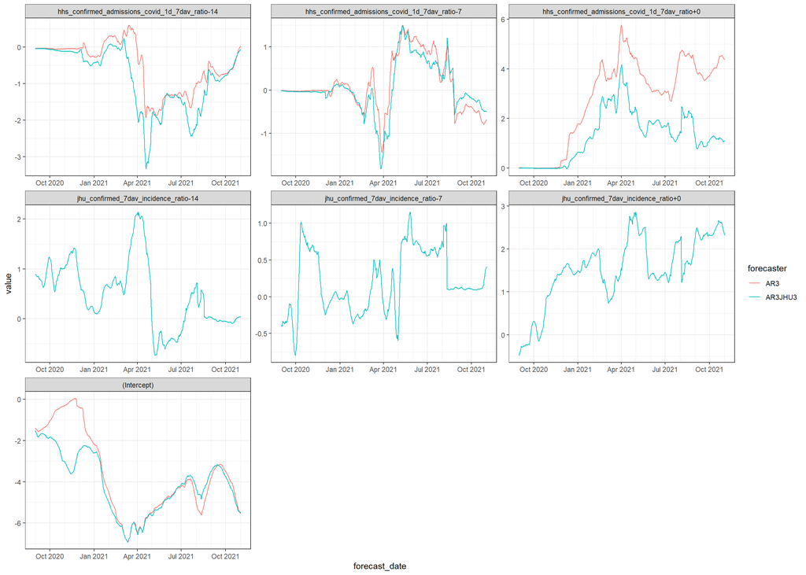

```r
ggplot(coefs %>% filter(ahead == 7), aes(x = forecast_date, y = value, color = forecaster)) +
    geom_point(cex = .25) +
    geom_line() +
    scale_x_date(date_minor_breaks = "1 month") +
    facet_wrap(vars(feature_name), scales = "free", ncol = 3)
```

#### 10 days ahead

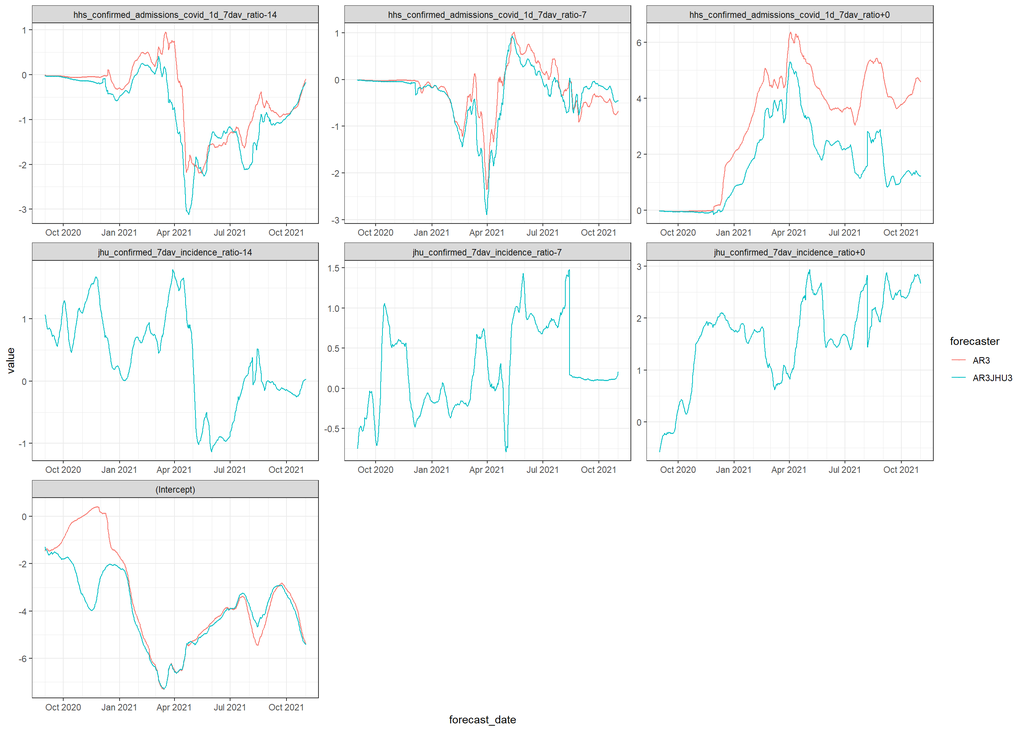

```r
ggplot(coefs %>% filter(ahead == 10), aes(x = forecast_date, y = value, color = forecaster)) +
    geom_point(cex = .25) +
    geom_line() +
    scale_x_date(date_minor_breaks = "1 month") +
    facet_wrap(vars(feature_name), scales = "free", ncol = 3)
```

#### 14 days ahead

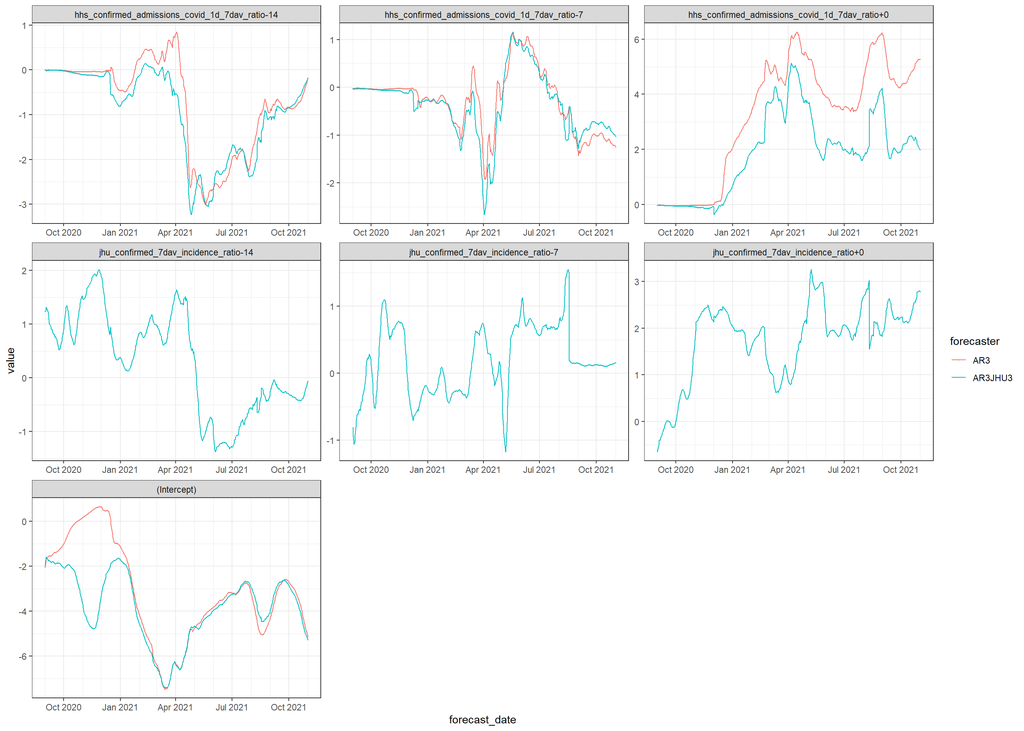

```r
ggplot(coefs %>% filter(ahead == 14), aes(x = forecast_date, y = value, color = forecaster)) +
    geom_point(cex = .25) +
    geom_line() +
    scale_x_date(date_minor_breaks = "1 month") +
    facet_wrap(vars(feature_name), scales = "free", ncol = 3)
```

#### 21 days ahead

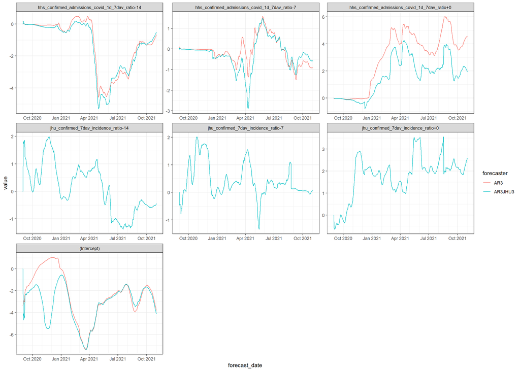

```r
ggplot(coefs %>% filter(ahead == 21), aes(x = forecast_date, y = value, color = forecaster)) +
    geom_point(cex = .25) +
    geom_line() +
    scale_x_date(date_minor_breaks = "1 month") +
    facet_wrap(vars(feature_name), scales = "free", ncol = 3)
```

### Smoothed

#### 7 days ahead

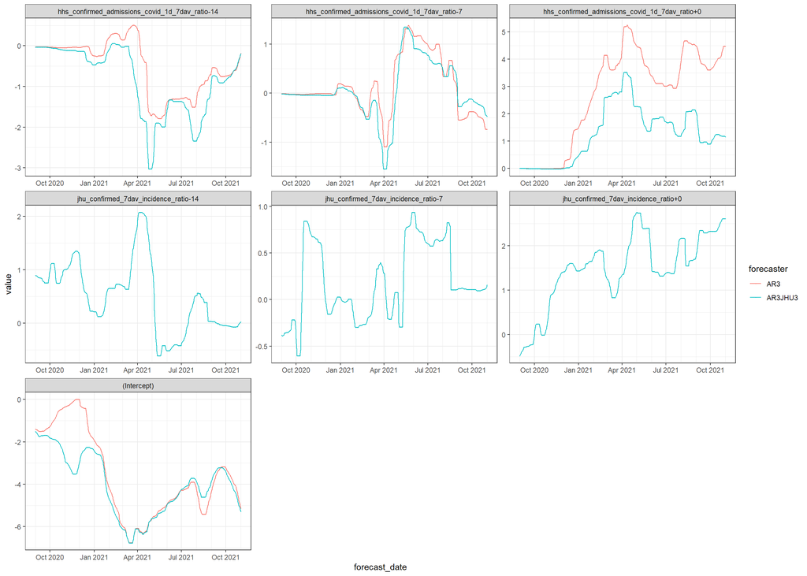

```r
ggplot(smoothed_coefs %>% filter(ahead == 7), aes(x = forecast_date, y = value, color = forecaster)) +
    geom_point(cex = .25) +
    geom_line() +
    scale_x_date(date_minor_breaks = "1 month") +
    facet_wrap(vars(feature_name), scales = "free", ncol = 3)
```

#### 10 days ahead

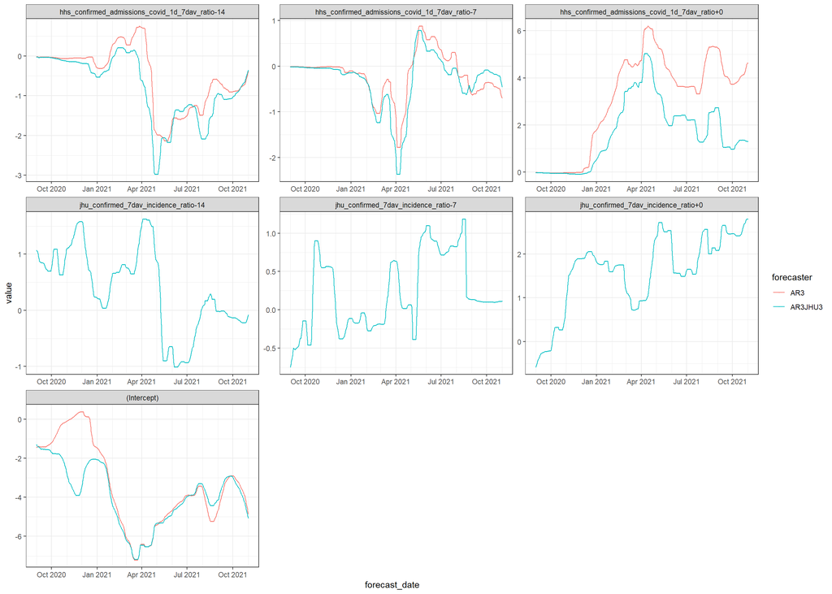

```r
ggplot(smoothed_coefs %>% filter(ahead == 10), aes(x = forecast_date, y = value, color = forecaster)) +
    geom_point(cex = .25) +
    geom_line() +
    scale_x_date(date_minor_breaks = "1 month") +
    facet_wrap(vars(feature_name), scales = "free", ncol = 3)
```

#### 14 days ahead

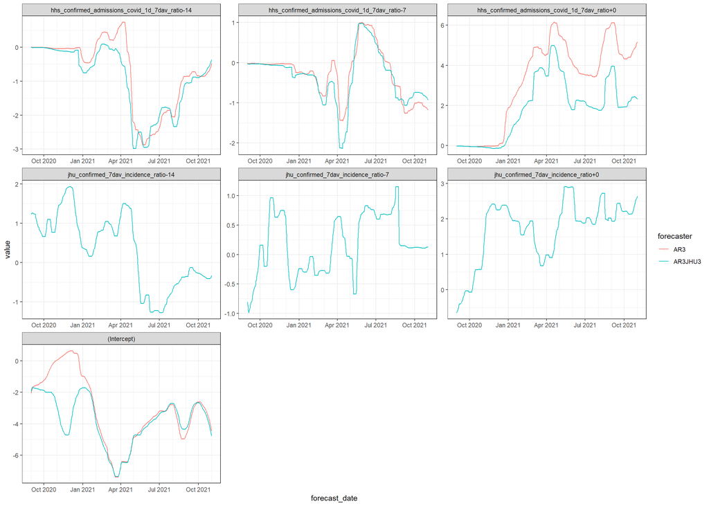

```r
ggplot(smoothed_coefs %>% filter(ahead == 14), aes(x = forecast_date, y = value, color = forecaster)) +
    geom_point(cex = .25) +
    geom_line() +
    scale_x_date(date_minor_breaks = "1 month") +
    facet_wrap(vars(feature_name), scales = "free", ncol = 3)
```

#### 21 days ahead

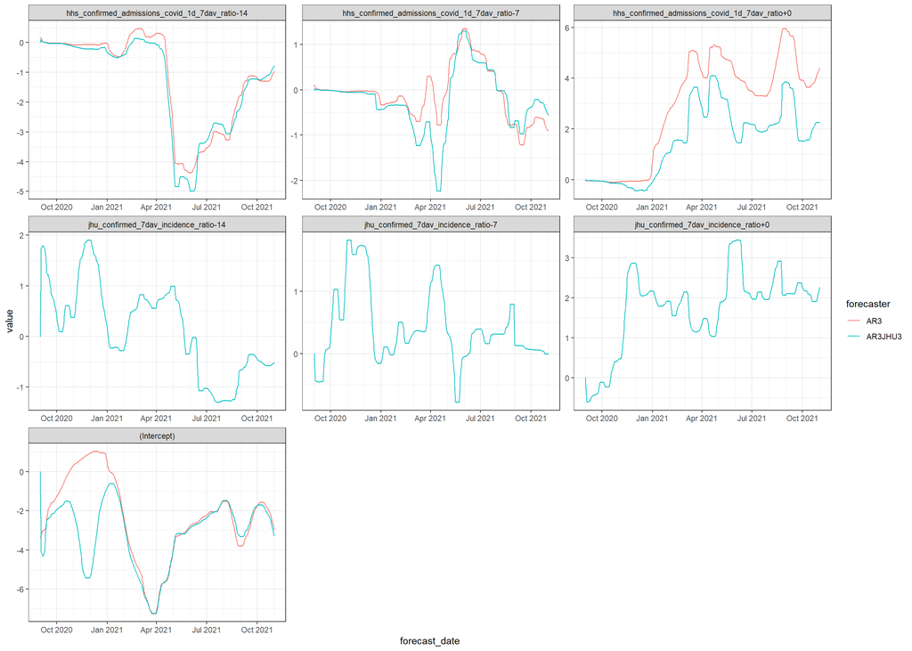

```r
ggplot(smoothed_coefs %>% filter(ahead == 21), aes(x = forecast_date, y = value, color = forecaster)) +
    geom_point(cex = .25) +
    geom_line() +
    scale_x_date(date_minor_breaks = "1 month") +
    facet_wrap(vars(feature_name), scales = "free", ncol = 3)
```